# Taboo: Analysis of target cards

Sean Trott

9/28/2020

# Introduction

In this document, we explore whether features of the **target word** explain variance in **trial outcomes** (e.g., success vs. loss). This can be seen as an extension to the **Behavioral Analysis** document, which attempts to identify experimental variables (`pair_type`, `trial_with_partner` that predict outcomes).

# Load behavioral data

Here, we load the behavioral results and quickly preprocess them in an identical way to the Behavioral Analysis.

```r
# read data
## setwd("/Users/seantrott/Dropbox/UCSD/Research/Ambiguity/Taboo/Experiment1/analysis/reports")
df = read.csv("../../data/processed/behavioral_results_public.csv")

df = df %>%
   filter(Native_Speaker == "Yes")
```

## Remove sessions 10 and 15

```r
df = df %>%
  filter((session_id %in% c(10, 15)) == FALSE)
df$word = tolower(df$card)
nrow(df)
```

```
## [1] 4204
```

# Load lexical statistics

Here, we load databases with the following information:

- Brysbaert concreteness norms
- SUBTLEX (for frequency measures)
- Kuperman et al Age of Acquisition measures

```r
## Concreteness norms
df_concreteness = read_csv("../../data/lexical_statistics/brysbaert_norms.csv")
df_concreteness$word = df_concreteness$Word
## SUBTLEX frequency data
df_subtlex = read_csv("../../data/lexical_statistics/SUBTLEXusfrequencyabove1.csv")
df_subtlex$word = df_subtlex$Word
## AoA norms
df_aoa = read_csv("../../data/lexical_statistics/AoA_ratings_Kuperman_et_al_BRM.csv")
df_aoa$AoA = df_aoa$Rating.Mean
df_aoa$word = tolower(df_aoa$Word)
```

We also load a dataset containing the average distance between the target word and each taboo word.

```r
df_distance_to_taboo = read_csv("../../data/lexical_statistics/taboo_with_distances.csv")
df_distance_to_taboo = df_distance_to_taboo %>%
  mutate(word = target) %>%
  drop_na(avg_distance_to_taboo) %>%
  dplyr::select(word, avg_distance_to_taboo) %>%
  filter(word %in% df$word)
nrow(df_distance_to_taboo)
```

```
## [1] 454
```

# Merge with Taboo data

We then merge that data with the Taboo data.

```r
df_merged = df %>%
  inner_join(df_concreteness, by = "word") %>%
  inner_join(df_subtlex, by = "word") %>%
  inner_join(df_aoa, by = "word") %>%
  inner_join(df_distance_to_taboo, by = "word")
nrow(df_merged)
```

```
## [1] 3731
```

```r
### Now remove critical NA observations for these columns
df_merged = df_merged %>%
  drop_na(Conc.M) %>%
  drop_na(Lg10WF) %>%
  drop_na(AoA)
nrow(df_merged)
```

```
## [1] 3731
```

```r
### Also restrict POS to Noun, Verb, and Adjective
df_merged = df_merged %>%
  filter(Dom_Pos %in% c("Noun", "Verb", "Adjective"))
nrow(df_merged)
```

```
## [1] 3702
```

```r
table(df_merged$Dom_Pos)
```

```
##
## Adjective      Noun      Verb
##       238      2972       492
```

```r
## Mean concreteness
df_merged_unique = df_merged %>%
  group_by(card) %>%
  summarise(conc = mean(Conc.M, na.rm = TRUE))
mean(df_merged_unique$conc)
```

```
## [1] 4.235361
```

```r
median(df_merged_unique$conc)
```

```
## [1] 4.59
```

# Primary analyses

## Is success (win vs. out of time) predicted by characteristics of the target word?

Note that past work (Zdrazilova et al, 2018) found that `Concreteness` predicted accuracy in a similar taboo expeirmental task. Here, we again ask whether `Concreteness` (using a continuous measure) and other lexical statistics predict trial success (`win` vs. `out of time`); a separate analysis asks whether these statistics predict `win` vs. `lose` (e.g., using a taboo gesture).

We first construct a full model containing all these lexical statistics, then compare that model to a series of reduced models omitting each in turn. The random factors and covariates (`trial_with_partner`) are chosen to reflect the factors found to be predictive in the Behavioral Analysis.

```r
df_win_lose = df_merged %>%
    filter(trial_result %in% c("Won", "Out of time"))
nrow(df_win_lose)
```

```
## [1] 2543
```

```r
model_full = glmer(data = df_win_lose,
                   trial_result ~
                     trial_with_partner +
                     Dom_Pos +
                     avg_distance_to_taboo +
                     Conc.M +
                     Lg10WF +
                     AoA +
                     (1 | ppt_id) +
                     (1 | partner_id) +
                     (1 | Order) +
                     (1 | session_id) +
                     (1 | color),
                   control=glmerControl(optimizer="bobyqa"),
                   family = binomial())
```

```
## boundary (singular) fit: see ?isSingular
```

```r
model_no_conc = glmer(data = df_win_lose,
                   trial_result ~
                     trial_with_partner +
                     avg_distance_to_taboo +
                     Dom_Pos +
                     # Conc.M +
                     Lg10WF +
                     AoA +
                     (1 | ppt_id) +
                     (1 | partner_id) +
                     (1 | Order) +
                     (1 | session_id) +
                     (1 | color),
                   control=glmerControl(optimizer="bobyqa"),
                   family = binomial())
```

```
## boundary (singular) fit: see ?isSingular
```

```r
model_no_aoa = glmer(data = df_win_lose,
                   trial_result ~
                     trial_with_partner +
                     avg_distance_to_taboo +
                     Dom_Pos +
                     Conc.M +
                     Lg10WF +
                    #  AoA +
                     (1 | ppt_id) +
                     (1 | partner_id) +
                     (1 | Order) +
                     (1 | session_id) +
                     (1 | color),
                   control=glmerControl(optimizer="bobyqa"),
                   family = binomial())
```

```
## boundary (singular) fit: see ?isSingular
```

```r
model_no_frequency = glmer(data = df_win_lose,
                   trial_result ~
                     trial_with_partner +
                     avg_distance_to_taboo +
                     Dom_Pos +
                     Conc.M +
                     # Lg10WF +
                     AoA +
                     (1 | ppt_id) +
                     (1 | partner_id) +
                     (1 | Order) +
                     (1 | session_id) +
                     (1 | color),
                   control=glmerControl(optimizer="bobyqa"),
                   family = binomial())
```

```
## boundary (singular) fit: see ?isSingular
```

```r
model_no_turn = glmer(data = df_win_lose,
                   trial_result ~
                     # trial_with_partner +
                     Dom_Pos +
                     avg_distance_to_taboo +
                     Conc.M +
                     Lg10WF +
                     AoA +
                     (1 | ppt_id) +
                     (1 | partner_id) +
                     (1 | Order) +
                     (1 | session_id) +
                     (1 | color),
                   control=glmerControl(optimizer="bobyqa"),
                   family = binomial())
```

```
## boundary (singular) fit: see ?isSingular
```

```r
model_no_pos = glmer(data = df_win_lose,
                   trial_result ~
                     trial_with_partner +
                     # Dom_Pos +
                     avg_distance_to_taboo +
                     Conc.M +
                     Lg10WF +
                     AoA +
                     (1 | ppt_id) +
                     (1 | partner_id) +
                     (1 | Order) +
                     (1 | session_id) +
                     (1 | color),
                   control=glmerControl(optimizer="bobyqa"),
                   family = binomial())
```

```
## boundary (singular) fit: see ?isSingular
```

```r
model_no_distance = glmer(data = df_win_lose,
                   trial_result ~
                     trial_with_partner +
                     Dom_Pos +
                     # avg_distance_to_taboo +
                     Conc.M +
                     Lg10WF +
                     AoA +
                     (1 | ppt_id) +
                     (1 | partner_id) +
                     (1 | Order) +
                     (1 | session_id) +
                     (1 | color),
                   control=glmerControl(optimizer="bobyqa"),
                   family = binomial())
```

```
## boundary (singular) fit: see ?isSingular
```

```r
comparison_conc = anova(model_full, model_no_conc)
comparison_conc
```

```
## Data: df_win_lose
## Models:
## model_no_conc: trial_result ~ trial_with_partner + avg_distance_to_taboo + Dom_Pos +
## model_no_conc:     Lg10WF + AoA + (1 | ppt_id) + (1 | partner_id) + (1 | Order) +
## model_no_conc:     (1 | session_id) + (1 | color)
## model_full: trial_result ~ trial_with_partner + Dom_Pos + avg_distance_to_taboo +
## model_full:     Conc.M + Lg10WF + AoA + (1 | ppt_id) + (1 | partner_id) +
## model_full:     (1 | Order) + (1 | session_id) + (1 | color)
##               npar    AIC    BIC  logLik deviance  Chisq Df Pr(>Chisq)
## model_no_conc   12 2146.6 2216.7 -1061.3   2122.6
## model_full      13 2126.8 2202.7 -1050.4   2100.8 21.812  1  3.007e-06 ***
## ---
## Signif. codes:  0 '***' 0.001 '**' 0.01 '*' 0.05 '.' 0.1 ' ' 1
```

```r
comparison_aoa = anova(model_full, model_no_aoa)
comparison_aoa
```

```
## Data: df_win_lose
## Models:
## model_no_aoa: trial_result ~ trial_with_partner + avg_distance_to_taboo + Dom_Pos +
## model_no_aoa:     Conc.M + Lg10WF + (1 | ppt_id) + (1 | partner_id) + (1 |
## model_no_aoa:     Order) + (1 | session_id) + (1 | color)
## model_full: trial_result ~ trial_with_partner + Dom_Pos + avg_distance_to_taboo +
## model_full:     Conc.M + Lg10WF + AoA + (1 | ppt_id) + (1 | partner_id) +
## model_full:     (1 | Order) + (1 | session_id) + (1 | color)
##              npar    AIC    BIC  logLik deviance  Chisq Df Pr(>Chisq)
## model_no_aoa   12 2144.2 2214.2 -1060.1   2120.2
## model_full     13 2126.8 2202.7 -1050.4   2100.8 19.355  1  1.086e-05 ***
## ---
## Signif. codes:  0 '***' 0.001 '**' 0.01 '*' 0.05 '.' 0.1 ' ' 1
```

```r
comparison_freq = anova(model_full, model_no_frequency)
comparison_freq
```

```
## Data: df_win_lose
## Models:
## model_no_frequency: trial_result ~ trial_with_partner + avg_distance_to_taboo + Dom_Pos +
## model_no_frequency:     Conc.M + AoA + (1 | ppt_id) + (1 | partner_id) + (1 | Order) +
## model_no_frequency:     (1 | session_id) + (1 | color)
## model_full: trial_result ~ trial_with_partner + Dom_Pos + avg_distance_to_taboo +
## model_full:     Conc.M + Lg10WF + AoA + (1 | ppt_id) + (1 | partner_id) +
## model_full:     (1 | Order) + (1 | session_id) + (1 | color)
##                    npar    AIC    BIC  logLik deviance  Chisq Df Pr(>Chisq)
## model_no_frequency   12 2155.2 2225.3 -1065.6   2131.2
## model_full           13 2126.8 2202.7 -1050.4   2100.8 30.369  1  3.571e-08 ***
## ---
## Signif. codes:  0 '***' 0.001 '**' 0.01 '*' 0.05 '.' 0.1 ' ' 1
```

```r
comparison_turn = anova(model_full, model_no_turn)
comparison_turn
```

```
## Data: df_win_lose
## Models:
## model_no_turn: trial_result ~ Dom_Pos + avg_distance_to_taboo + Conc.M + Lg10WF +
## model_no_turn:     AoA + (1 | ppt_id) + (1 | partner_id) + (1 | Order) + (1 |
## model_no_turn:     session_id) + (1 | color)
## model_full: trial_result ~ trial_with_partner + Dom_Pos + avg_distance_to_taboo +
## model_full:     Conc.M + Lg10WF + AoA + (1 | ppt_id) + (1 | partner_id) +
## model_full:     (1 | Order) + (1 | session_id) + (1 | color)
##               npar    AIC    BIC  logLik deviance Chisq Df Pr(>Chisq)
## model_no_turn   12 2132.7 2202.8 -1054.4   2108.7
## model_full      13 2126.8 2202.7 -1050.4   2100.8 7.922  1   0.004884 **
## ---
## Signif. codes:  0 '***' 0.001 '**' 0.01 '*' 0.05 '.' 0.1 ' ' 1
```

```r
comparison_pos = anova(model_full, model_no_pos)
comparison_pos
```

```
## Data: df_win_lose
## Models:
## model_no_pos: trial_result ~ trial_with_partner + avg_distance_to_taboo + Conc.M +
## model_no_pos:     Lg10WF + AoA + (1 | ppt_id) + (1 | partner_id) + (1 | Order) +
## model_no_pos:     (1 | session_id) + (1 | color)
## model_full: trial_result ~ trial_with_partner + Dom_Pos + avg_distance_to_taboo +
## model_full:     Conc.M + Lg10WF + AoA + (1 | ppt_id) + (1 | partner_id) +
## model_full:     (1 | Order) + (1 | session_id) + (1 | color)
##              npar    AIC    BIC  logLik deviance  Chisq Df Pr(>Chisq)
## model_no_pos   11 2128.5 2192.8 -1053.3   2106.5
## model_full     13 2126.8 2202.7 -1050.4   2100.8 5.7288  2    0.05702 .
## ---
## Signif. codes:  0 '***' 0.001 '**' 0.01 '*' 0.05 '.' 0.1 ' ' 1
```

```r
comparison_distance = anova(model_full, model_no_distance)
comparison_distance
```

```
## Data: df_win_lose
## Models:
## model_no_distance: trial_result ~ trial_with_partner + Dom_Pos + Conc.M + Lg10WF +
## model_no_distance:     AoA + (1 | ppt_id) + (1 | partner_id) + (1 | Order) + (1 |
## model_no_distance:     session_id) + (1 | color)
## model_full: trial_result ~ trial_with_partner + Dom_Pos + avg_distance_to_taboo +
## model_full:     Conc.M + Lg10WF + AoA + (1 | ppt_id) + (1 | partner_id) +
## model_full:     (1 | Order) + (1 | session_id) + (1 | color)
##                   npar    AIC    BIC  logLik deviance  Chisq Df Pr(>Chisq)
## model_no_distance   12 2126.5 2196.6 -1051.2   2102.5
## model_full          13 2126.8 2202.7 -1050.4   2100.8 1.6975  1     0.1926
```

We can also visualize coefficients from the full model:

```r
summary(model_full)
```

```
## Generalized linear mixed model fit by maximum likelihood (Laplace
##   Approximation) [glmerMod]
##  Family: binomial  ( logit )
## Formula: trial_result ~ trial_with_partner + Dom_Pos + avg_distance_to_taboo +
##     Conc.M + Lg10WF + AoA + (1 | ppt_id) + (1 | partner_id) +
##     (1 | Order) + (1 | session_id) + (1 | color)
##    Data: df_win_lose
## Control: glmerControl(optimizer = "bobyqa")
##
##      AIC      BIC   logLik deviance df.resid
##   2126.8   2202.7  -1050.4   2100.8     2530
##
## Scaled residuals:
##     Min      1Q  Median      3Q     Max
## -6.0540  0.1873  0.3192  0.4823  2.0250
##
## Random effects:
##  Groups     Name        Variance Std.Dev.
##  partner_id (Intercept) 0.01503  0.1226
##  ppt_id     (Intercept) 0.03365  0.1834
##  session_id (Intercept) 0.49201  0.7014
##  color      (Intercept) 0.04226  0.2056
##  Order      (Intercept) 0.00000  0.0000
## Number of obs: 2543, groups:
## partner_id, 68; ppt_id, 65; session_id, 17; color, 4; Order, 2
##
## Fixed effects:
##                        Estimate Std. Error z value Pr(>|z|)
## (Intercept)           -1.374405   0.859196  -1.600  0.10968
## trial_with_partner     0.017696   0.006254   2.830  0.00466 **
## Dom_PosNoun           -0.231080   0.240356  -0.961  0.33635
## Dom_PosVerb            0.216286   0.278482   0.777  0.43736
## avg_distance_to_taboo  0.842283   0.642956   1.310  0.19019
## Conc.M                 0.374966   0.079000   4.746 2.07e-06 ***
## Lg10WF                 0.616502   0.112933   5.459 4.79e-08 ***
## AoA                   -0.127469   0.028783  -4.429 9.48e-06 ***
## ---
## Signif. codes:  0 '***' 0.001 '**' 0.01 '*' 0.05 '.' 0.1 ' ' 1
##
## Correlation of Fixed Effects:
##             (Intr) trl_w_ Dm_PsN Dm_PsV avg___ Conc.M Lg10WF
## trl_wth_prt -0.132
## Dom_PosNoun -0.072  0.013
## Dom_PosVerb -0.129 -0.003  0.728
## avg_dstnc__ -0.683 -0.004 -0.057 -0.127
## Conc.M      -0.447  0.032 -0.387 -0.096  0.017
## Lg10WF      -0.775  0.019 -0.010  0.020  0.515  0.204
## AoA         -0.503 -0.006 -0.014  0.101  0.016  0.320  0.400
## convergence code: 0
## boundary (singular) fit: see ?isSingular
```

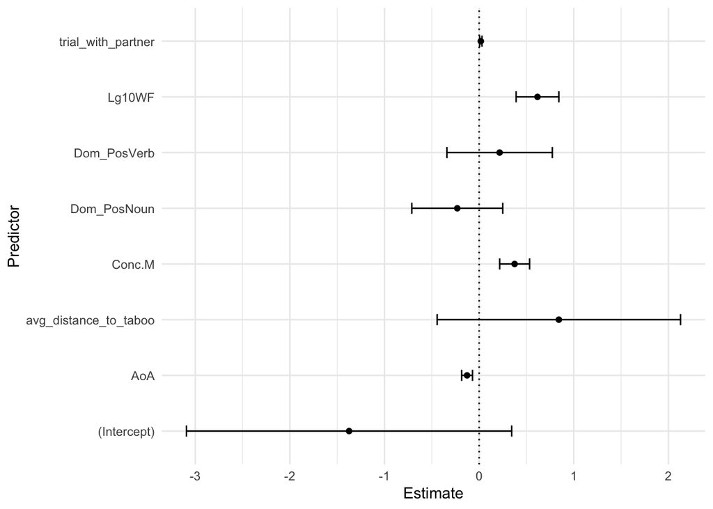

```r
df_tidy = broom.mixed::tidy(model_full)

df_tidy %>%
  filter(effect == "fixed") %>%
  ggplot(aes(x = term,
             y = estimate)) +
  geom_point() +
  coord_flip() +
  geom_hline(yintercept = 0, linetype = "dotted") +
  geom_errorbar(aes(ymin = estimate - 2*std.error,
                    ymax = estimate + 2*std.error),
                width=.2,
                position=position_dodge(.9)) +
  labs(x = "Predictor",
       y = "Estimate") +
  theme_minimal()
```

Now we correct for multiple comparisons.

```r
p.adjust(c(comparison_conc$`Pr(>Chisq)`[2],
           comparison_aoa$`Pr(>Chisq)`[2],
           comparison_freq$`Pr(>Chisq)`[2],
           comparison_turn$`Pr(>Chisq)`[2],
           comparison_pos$`Pr(>Chisq)`[2],
           comparison_distance$`Pr(>Chisq)`[2]),
         method="holm")
```

```
## [1] 1.503627e-05 4.342574e-05 2.142895e-07 1.465147e-02 1.140340e-01
## [6] 1.926117e-01
```

We can also visualize these new findings about the lexical statistics:

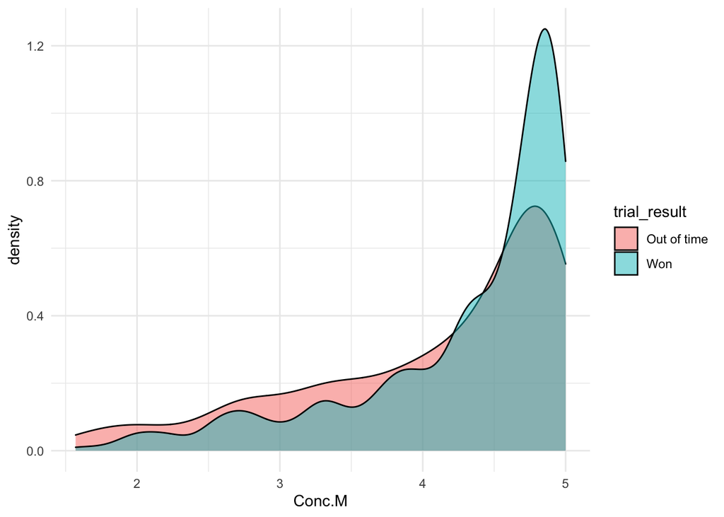

```r
df_win_lose %>%
  ggplot(aes(x = Conc.M,
             fill = trial_result)) +
  geom_density(alpha = .5) +
  theme_minimal()
```

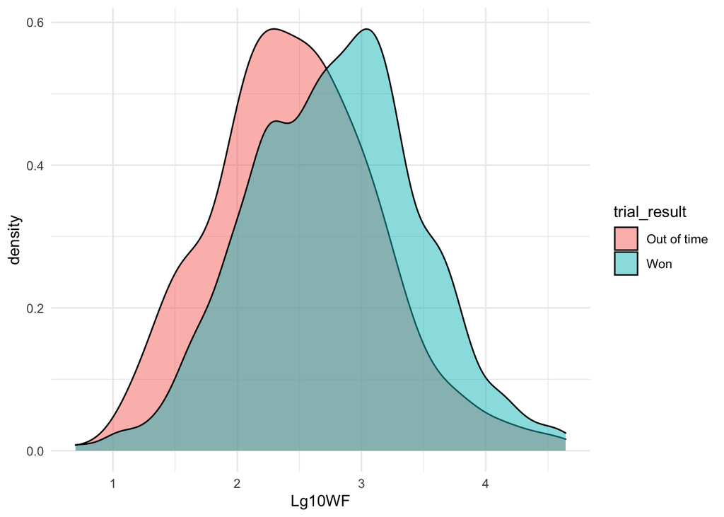

```r
df_win_lose %>%
  ggplot(aes(x = Lg10WF,
             fill = trial_result)) +
  geom_density(alpha = .5) +
  theme_minimal()
```

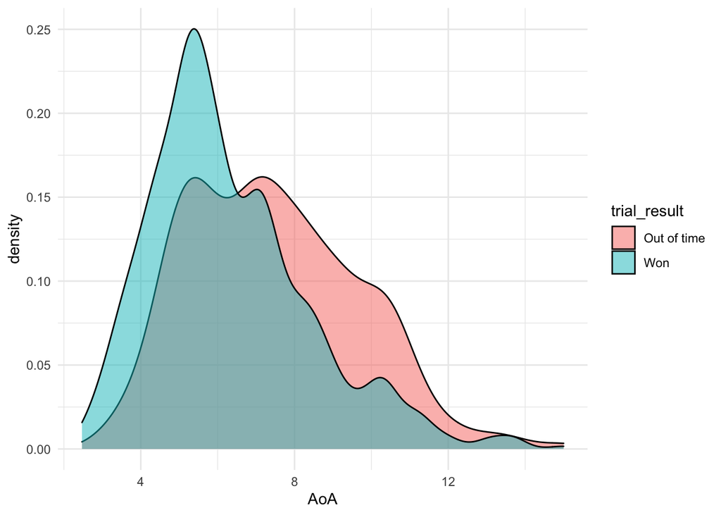

```r
df_win_lose %>%
  ggplot(aes(x = AoA,
             fill = trial_result)) +
  geom_density(alpha = .5) +
  theme_minimal()
```

We can also visualize each together:

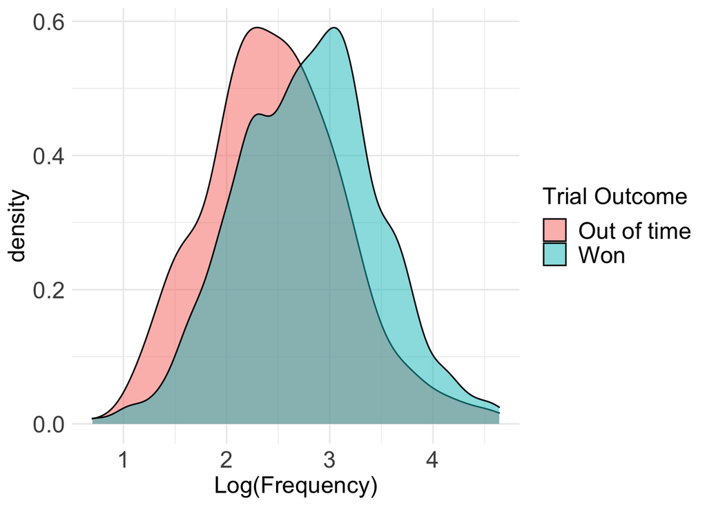

```r
df_win_lose %>%
  ggplot(aes(x = Lg10WF,
             fill = trial_result)) +
  geom_density(alpha = .5) +
  labs(x = "Log(Frequency)",
       fill = "Trial Outcome") +
  theme_minimal() +
  theme(axis.title = element_text(size=rel(1.5)),
        axis.text = element_text(size = rel(1.5)),
        legend.text = element_text(size = rel(1.5)),
        strip.text.x = element_text(size = rel(1.5)),
        plot.title = element_text(size = rel(1.5)),
        legend.title = element_text(size = rel(1.5)))
```

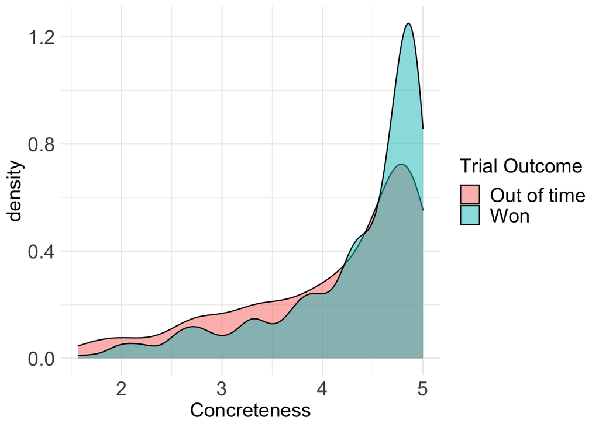

```r
ggsave("../../Figures/target_word/frequency.png", dpi = 300)
df_win_lose %>%
  ggplot(aes(x = Conc.M,
             fill = trial_result)) +
  geom_density(alpha = .5) +
  labs(x = "Concreteness",
       fill = "Trial Outcome") +
  theme_minimal() +
  theme(axis.title = element_text(size=rel(1.5)),
        axis.text = element_text(size = rel(1.5)),
        legend.text = element_text(size = rel(1.5)),
        strip.text.x = element_text(size = rel(1.5)),
        plot.title = element_text(size = rel(1.5)),
        legend.title = element_text(size = rel(1.5)))
```

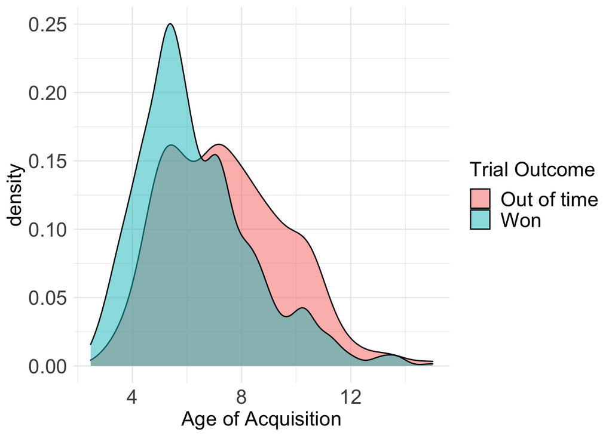

```r
ggsave("../../Figures/target_word/concreteness.png", dpi = 300)
df_win_lose %>%
  ggplot(aes(x = AoA,
             fill = trial_result)) +
  geom_density(alpha = .5) +
  labs(x = "Age of Acquisition",
       fill = "Trial Outcome") +
  theme_minimal() +
  theme(axis.title = element_text(size=rel(1.5)),
        axis.text = element_text(size = rel(1.5)),
        legend.text = element_text(size = rel(1.5)),
        strip.text.x = element_text(size = rel(1.5)),
        plot.title = element_text(size = rel(1.5)),
        legend.title = element_text(size = rel(1.5)))
```

```r
ggsave("../../Figures/target_word/aoa.png", dpi = 300)
```

## Is outcome (win vs. lose) predicted by lexical statistics?

Here, we run the same analyses as above but for a different contrast: `win` vs. `lose` (where "lose" is defined by using a taboo word or gesture).

```r
df_win_lose2 = df_merged %>%
    filter(trial_result %in% c("Won", "Lost"))
nrow(df_win_lose2)
```

```
## [1] 3251
```

```r
model_full = glmer(data = df_win_lose2,
                   trial_result ~
                     trial_with_partner +
                     avg_distance_to_taboo +
                     Dom_Pos +
                     Conc.M +
                     Lg10WF +
                     AoA +
                     (1 | ppt_id) +
                     (1 | partner_id) +
                     (1 | Order) +
                     (1 | session_id) +
                     (1 | color),
                   control=glmerControl(optimizer="bobyqa"),
                   family = binomial())
```

```
## boundary (singular) fit: see ?isSingular
```

```r
model_no_conc = glmer(data = df_win_lose2,
                   trial_result ~
                     trial_with_partner +
                     Dom_Pos +
                     # Conc.M +
                     avg_distance_to_taboo +
                     Lg10WF +
                     AoA +
                     (1 | ppt_id) +
                     (1 | partner_id) +
                     (1 | Order) +
                     (1 | session_id) +
                     (1 | color),
                   control=glmerControl(optimizer="bobyqa"),
                   family = binomial())
```

```
## boundary (singular) fit: see ?isSingular
```

```r
model_no_aoa = glmer(data = df_win_lose2,
                   trial_result ~
                     trial_with_partner +
                     Dom_Pos +
                     avg_distance_to_taboo +
                     Conc.M +
                     Lg10WF +
                    #  AoA +
                     (1 | ppt_id) +
                     (1 | partner_id) +
                     (1 | Order) +
                     (1 | session_id) +
                     (1 | color),
                   control=glmerControl(optimizer="bobyqa"),
                   family = binomial())
```

```
## boundary (singular) fit: see ?isSingular
```

```r
model_no_frequency = glmer(data = df_win_lose2,
                   trial_result ~
                     trial_with_partner +
                     Dom_Pos +
                     avg_distance_to_taboo +
                     Conc.M +
                     # Lg10WF +
                     AoA +
                     (1 | ppt_id) +
                     (1 | partner_id) +
                     (1 | Order) +
                     (1 | session_id) +
                     (1 | color),
                   control=glmerControl(optimizer="bobyqa"),
                   family = binomial())
```

```
## boundary (singular) fit: see ?isSingular
```

```r
model_no_turn = glmer(data = df_win_lose2,
                   trial_result ~
                     # trial_with_partner +
                     Dom_Pos +
                     avg_distance_to_taboo +
                     Conc.M +
                     Lg10WF +
                     AoA +
                     (1 | ppt_id) +
                     (1 | partner_id) +
                     (1 | Order) +
                     (1 | session_id) +
                     (1 | color),
                   control=glmerControl(optimizer="bobyqa"),
                   family = binomial())
```

```
## boundary (singular) fit: see ?isSingular
```

```r
model_no_pos = glmer(data = df_win_lose2,
                   trial_result ~
                     trial_with_partner +
                     # Dom_Pos +
                     avg_distance_to_taboo +
                     Conc.M +
                     Lg10WF +
                     AoA +
                     (1 | ppt_id) +
                     (1 | partner_id) +
                     (1 | Order) +
                     (1 | session_id) +
                     (1 | color),
                   control=glmerControl(optimizer="bobyqa"),
                   family = binomial())
```

```
## boundary (singular) fit: see ?isSingular
```

```r
model_no_distance = glmer(data = df_win_lose2,
                   trial_result ~
                     trial_with_partner +
                     Dom_Pos +
                     # avg_distance_to_taboo +
                     Conc.M +
                     Lg10WF +
                     AoA +
                     (1 | ppt_id) +
                     (1 | partner_id) +
                     (1 | Order) +
                     (1 | session_id) +
                     (1 | color),
                   control=glmerControl(optimizer="bobyqa"),
                   family = binomial())
```

```
## boundary (singular) fit: see ?isSingular
```

```r
comparison_conc = anova(model_full, model_no_conc)
comparison_conc
```

```
## Data: df_win_lose2
## Models:
## model_no_conc: trial_result ~ trial_with_partner + Dom_Pos + avg_distance_to_taboo +
## model_no_conc:     Lg10WF + AoA + (1 | ppt_id) + (1 | partner_id) + (1 | Order) +
## model_no_conc:     (1 | session_id) + (1 | color)
## model_full: trial_result ~ trial_with_partner + avg_distance_to_taboo + Dom_Pos +
## model_full:     Conc.M + Lg10WF + AoA + (1 | ppt_id) + (1 | partner_id) +
## model_full:     (1 | Order) + (1 | session_id) + (1 | color)
##               npar    AIC    BIC  logLik deviance  Chisq Df Pr(>Chisq)
## model_no_conc   12 3979.4 4052.4 -1977.7   3955.4
## model_full      13 3960.7 4039.9 -1967.4   3934.7 20.665  1   5.47e-06 ***
## ---
## Signif. codes:  0 '***' 0.001 '**' 0.01 '*' 0.05 '.' 0.1 ' ' 1
```

```r
comparison_aoa = anova(model_full, model_no_aoa)
comparison_aoa
```

```
## Data: df_win_lose2
## Models:
## model_no_aoa: trial_result ~ trial_with_partner + Dom_Pos + avg_distance_to_taboo +
## model_no_aoa:     Conc.M + Lg10WF + (1 | ppt_id) + (1 | partner_id) + (1 |
## model_no_aoa:     Order) + (1 | session_id) + (1 | color)
## model_full: trial_result ~ trial_with_partner + avg_distance_to_taboo + Dom_Pos +
## model_full:     Conc.M + Lg10WF + AoA + (1 | ppt_id) + (1 | partner_id) +
## model_full:     (1 | Order) + (1 | session_id) + (1 | color)
##              npar    AIC    BIC  logLik deviance  Chisq Df Pr(>Chisq)
## model_no_aoa   12 3972.4 4045.5 -1974.2   3948.4
## model_full     13 3960.7 4039.9 -1967.4   3934.7 13.698  1  0.0002147 ***
## ---
## Signif. codes:  0 '***' 0.001 '**' 0.01 '*' 0.05 '.' 0.1 ' ' 1
```

```r
comparison_freq = anova(model_full, model_no_frequency)
comparison_freq
```

```
## Data: df_win_lose2
## Models:
## model_no_frequency: trial_result ~ trial_with_partner + Dom_Pos + avg_distance_to_taboo +
## model_no_frequency:     Conc.M + AoA + (1 | ppt_id) + (1 | partner_id) + (1 | Order) +
## model_no_frequency:     (1 | session_id) + (1 | color)
## model_full: trial_result ~ trial_with_partner + avg_distance_to_taboo + Dom_Pos +
## model_full:     Conc.M + Lg10WF + AoA + (1 | ppt_id) + (1 | partner_id) +
## model_full:     (1 | Order) + (1 | session_id) + (1 | color)
##                    npar    AIC    BIC  logLik deviance  Chisq Df Pr(>Chisq)
## model_no_frequency   12 4020.6 4093.6 -1998.3   3996.6
## model_full           13 3960.7 4039.9 -1967.4   3934.7 61.845  1  3.716e-15 ***
## ---
## Signif. codes:  0 '***' 0.001 '**' 0.01 '*' 0.05 '.' 0.1 ' ' 1
```

```r
comparison_turn = anova(model_full, model_no_turn)
comparison_turn
```

```
## Data: df_win_lose2
## Models:
## model_no_turn: trial_result ~ Dom_Pos + avg_distance_to_taboo + Conc.M + Lg10WF +
## model_no_turn:     AoA + (1 | ppt_id) + (1 | partner_id) + (1 | Order) + (1 |
## model_no_turn:     session_id) + (1 | color)
## model_full: trial_result ~ trial_with_partner + avg_distance_to_taboo + Dom_Pos +
## model_full:     Conc.M + Lg10WF + AoA + (1 | ppt_id) + (1 | partner_id) +
## model_full:     (1 | Order) + (1 | session_id) + (1 | color)
##               npar    AIC    BIC  logLik deviance  Chisq Df Pr(>Chisq)
## model_no_turn   12 3974.3 4047.3 -1975.2   3950.3
## model_full      13 3960.7 4039.9 -1967.4   3934.7 15.559  1  7.997e-05 ***
## ---
## Signif. codes:  0 '***' 0.001 '**' 0.01 '*' 0.05 '.' 0.1 ' ' 1
```

```r
comparison_pos = anova(model_full, model_no_pos)
comparison_pos
```

```
## Data: df_win_lose2
## Models:
## model_no_pos: trial_result ~ trial_with_partner + avg_distance_to_taboo + Conc.M +
## model_no_pos:     Lg10WF + AoA + (1 | ppt_id) + (1 | partner_id) + (1 | Order) +
## model_no_pos:     (1 | session_id) + (1 | color)
## model_full: trial_result ~ trial_with_partner + avg_distance_to_taboo + Dom_Pos +
## model_full:     Conc.M + Lg10WF + AoA + (1 | ppt_id) + (1 | partner_id) +
## model_full:     (1 | Order) + (1 | session_id) + (1 | color)
##              npar    AIC    BIC  logLik deviance  Chisq Df Pr(>Chisq)
## model_no_pos   11 3959.0 4026.0 -1968.5   3937.0
## model_full     13 3960.7 4039.9 -1967.4   3934.7 2.3069  2     0.3155
```

```r
comparison_distance = anova(model_full, model_no_distance)
comparison_distance
```

```
## Data: df_win_lose2
## Models:
## model_no_distance: trial_result ~ trial_with_partner + Dom_Pos + Conc.M + Lg10WF +
## model_no_distance:     AoA + (1 | ppt_id) + (1 | partner_id) + (1 | Order) + (1 |
## model_no_distance:     session_id) + (1 | color)
## model_full: trial_result ~ trial_with_partner + avg_distance_to_taboo + Dom_Pos +
## model_full:     Conc.M + Lg10WF + AoA + (1 | ppt_id) + (1 | partner_id) +
## model_full:     (1 | Order) + (1 | session_id) + (1 | color)
##                   npar    AIC    BIC  logLik deviance Chisq Df Pr(>Chisq)
## model_no_distance   12 3960.4 4033.5 -1968.2   3936.4
## model_full          13 3960.7 4039.9 -1967.4   3934.7 1.695  1     0.1929
```

We can also visualize coefficients from the full model:

```r
summary(model_full)
```

```
## Generalized linear mixed model fit by maximum likelihood (Laplace
##   Approximation) [glmerMod]
##  Family: binomial  ( logit )
## Formula: trial_result ~ trial_with_partner + avg_distance_to_taboo + Dom_Pos +
##     Conc.M + Lg10WF + AoA + (1 | ppt_id) + (1 | partner_id) +
##     (1 | Order) + (1 | session_id) + (1 | color)
##    Data: df_win_lose2
## Control: glmerControl(optimizer = "bobyqa")
##
##      AIC      BIC   logLik deviance df.resid
##   3960.7   4039.9  -1967.4   3934.7     3238
##
## Scaled residuals:
##     Min      1Q  Median      3Q     Max
## -3.3979 -0.9782  0.5182  0.7220  2.1629
##
## Random effects:
##  Groups     Name        Variance  Std.Dev.
##  partner_id (Intercept) 1.042e-02 1.021e-01
##  ppt_id     (Intercept) 7.904e-09 8.890e-05
##  session_id (Intercept) 1.654e-01 4.067e-01
##  color      (Intercept) 8.875e-04 2.979e-02
##  Order      (Intercept) 4.103e-16 2.026e-08
## Number of obs: 3251, groups:
## partner_id, 68; ppt_id, 65; session_id, 17; color, 4; Order, 2
##
## Fixed effects:
##                        Estimate Std. Error z value Pr(>|z|)
## (Intercept)           -1.555136   0.598995  -2.596 0.009425 **
## trial_with_partner    -0.014873   0.003777  -3.938 8.21e-05 ***
## avg_distance_to_taboo  0.581516   0.446729   1.302 0.193012
## Dom_PosNoun           -0.038751   0.173558  -0.223 0.823321
## Dom_PosVerb           -0.213618   0.189752  -1.126 0.260262
## Conc.M                 0.257320   0.056630   4.544 5.52e-06 ***
## Lg10WF                 0.593766   0.076614   7.750 9.18e-15 ***
## AoA                   -0.076220   0.020625  -3.696 0.000219 ***
## ---
## Signif. codes:  0 '***' 0.001 '**' 0.01 '*' 0.05 '.' 0.1 ' ' 1
##
## Correlation of Fixed Effects:
##             (Intr) trl_w_ avg___ Dm_PsN Dm_PsV Conc.M Lg10WF
## trl_wth_prt -0.108
## avg_dstnc__ -0.695  0.001
## Dom_PosNoun -0.103 -0.007 -0.021
## Dom_PosVerb -0.131 -0.010 -0.111  0.775
## Conc.M      -0.450 -0.009  0.004 -0.381 -0.131
## Lg10WF      -0.785  0.008  0.521  0.037  0.001  0.187
## AoA         -0.538  0.001  0.058 -0.042  0.078  0.347  0.426
## convergence code: 0
## boundary (singular) fit: see ?isSingular
```

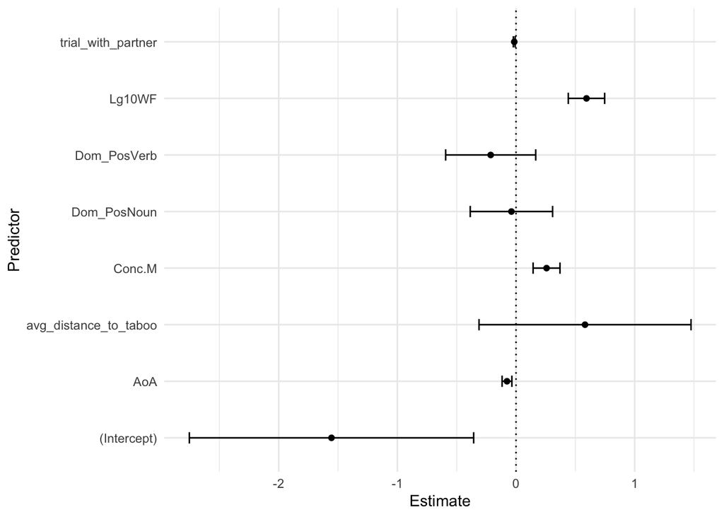

```r
df_tidy = broom.mixed::tidy(model_full)

df_tidy %>%
  filter(effect == "fixed") %>%
  ggplot(aes(x = term,
             y = estimate)) +
  geom_point() +
  coord_flip() +
  geom_hline(yintercept = 0, linetype = "dotted") +
  geom_errorbar(aes(ymin = estimate - 2*std.error,
                    ymax = estimate + 2*std.error),
                width=.2,
                position=position_dodge(.9)) +
  labs(x = "Predictor",
       y = "Estimate") +
  theme_minimal()
```

Now we correct for multiple comparisons.

```r
p.adjust(c(comparison_conc$`Pr(>Chisq)`[2],
           comparison_aoa$`Pr(>Chisq)`[2],
           comparison_freq$`Pr(>Chisq)`[2],
           comparison_turn$`Pr(>Chisq)`[2],
           comparison_pos$`Pr(>Chisq)`[2],
           comparison_distance$`Pr(>Chisq)`[2]),
         method="holm")
```

```
## [1] 2.735181e-05 6.441242e-04 2.229628e-14 3.198816e-04 3.858850e-01
## [6] 3.858850e-01
```

We can also visualize these new findings about the lexical statistics:

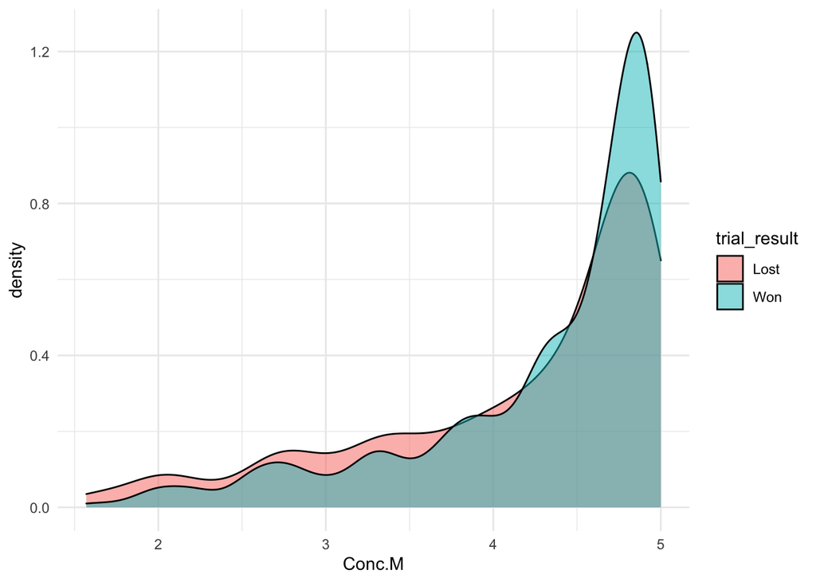

```r
df_win_lose2 %>%
  ggplot(aes(x = Conc.M,
             fill = trial_result)) +
  geom_density(alpha = .5) +
  theme_minimal()
```

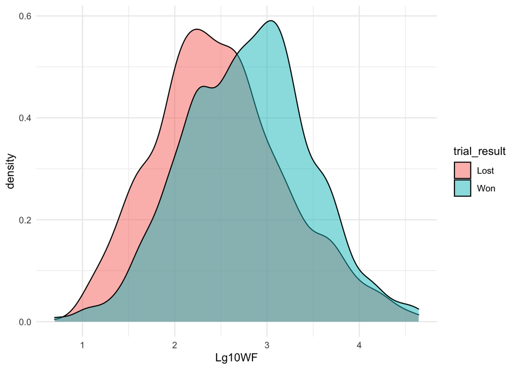

```r
df_win_lose2 %>%
  ggplot(aes(x = Lg10WF,
             fill = trial_result)) +
  geom_density(alpha = .5) +
  theme_minimal()
```

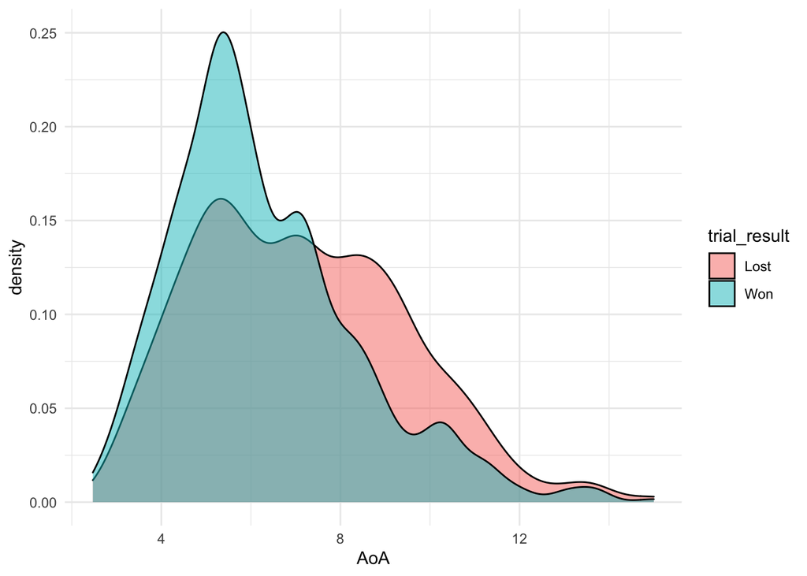

```r
df_win_lose2 %>%
  ggplot(aes(x = AoA,
             fill = trial_result)) +
  geom_density(alpha = .5) +
  theme_minimal()
```